# Reproducible Research Peer Assessment 2

## Population and economic impact of major weather events in the United States between 1950 and 2011

## Synopsis

The aim of this report is to examine the major storm and weather event database collected by the US National Oceanic and Atmospheric Administration (NOAA) between the years of 1950 and 2011 to ascertain which types of weather events cause the greatest population and economic damage to the US.

For the purpose of population harm, figures for estimated fatalities and injuries were extracted from the database and for the purpose of economic harm, figures for estimated property damage and crop loss were extracted. Both sets were then summed up by event type and then ordered from greatest to least impact.

The analysis will show that Tornadoes produce by far the most population harm of all weather events in the US, where as the lions share of the economic impact can be attributed to Floods, with Hurricanes, Tornadoes, and Storm Surges contributing heavily.

## Data Processing

We want to first download the data set from [link](https://d396qusza40orc.cloudfront.net/repdata%2Fdata%2FStormData.csv.bz2).

Loading the entire database into R to be able to examine the data and determine what sort of analysis is required.

```r
library(R.utils)
bunzip2("StormData.csv.bz2")
storm.data <- read.csv("StormData.csv")
head(storm.data)
```

```
##   STATE__           BGN_DATE BGN_TIME TIME_ZONE COUNTY COUNTYNAME STATE
## 1       1  4/18/1950 0:00:00     0130       CST     97     MOBILE    AL
## 2       1  4/18/1950 0:00:00     0145       CST      3    BALDWIN    AL
## 3       1  2/20/1951 0:00:00     1600       CST     57    FAYETTE    AL
## 4       1   6/8/1951 0:00:00     0900       CST     89    MADISON    AL
## 5       1 11/15/1951 0:00:00     1500       CST     43    CULLMAN    AL
## 6       1 11/15/1951 0:00:00     2000       CST     77 LAUDERDALE    AL
##    EVTYPE BGN_RANGE BGN_AZI BGN_LOCATI END_DATE END_TIME COUNTY_END
## 1 TORNADO         0                                               0
## 2 TORNADO         0                                               0
## 3 TORNADO         0                                               0
## 4 TORNADO         0                                               0
## 5 TORNADO         0                                               0
## 6 TORNADO         0                                               0
##   COUNTYENDN END_RANGE END_AZI END_LOCATI LENGTH WIDTH F MAG FATALITIES
```

[output cut: 20 more lines]

A quick look at the data tells us that we have far more variables than we’re interested in, that much of the data is missing, and that all the column names are in full caps. These issues will need to be rectified before advancing to the analysis.

```r
names(storm.data) <- tolower(names(storm.data))
```

### Cleaning the data

##### Population

First we will clean the population oriented data by summing all the fatalities and injuries per each event type and combining the results into a single data set. In the resulting data set we add the fatality and injury sums and then remove any events which have neither.

```r
    event.fat <- aggregate(fatalities ~ evtype, data = storm.data, sum)
    event.inj <- aggregate(injuries ~ evtype, data = storm.data, sum)
        event <- merge(event.fat, event.inj, "evtype")
  event$total <- event$fatalities + event$injuries
    event.pop <- event[rowSums(event[, -1] > 0) != 0, ]
```

##### Economic

Next we can clean the economic data, however closer inspection of the storm.data set reveals an untidy form of each of the property and crop damage value whereby a helper column contains an exponent code. For the purposes of this analysis we will address only the figures which range in the millions and billions.

We extract each column of interest and combine into a single data frame, ignoring any observations which don’t contain a million/billion exponent code.

```r
evtype <- storm.data$evtype
prop.d <- storm.data$propdmg
prop.x <- storm.data$propdmgexp
crop.d <- storm.data$cropdmg
crop.x <- storm.data$cropdmgexp

   dmg <- data.frame(evtype, prop.d, prop.x, crop.d, crop.x)
   dmg <- subset(dmg, grepl("[MmBb]", dmg$prop.x) | grepl("[MmBb]", dmg$crop.x))
```

Then we convert the exponent values to numeric.

```r
for (i in 1:nrow(dmg)) {
    if (grepl("[Mm]", dmg$prop.x[i])) {
        dmg$prop.d[i] <- 1e+06 * dmg$prop.d[i]
    }
    if (grepl("[Bb]", dmg$prop.x[i])) {
        dmg$prop.d[i] <- 1e+09 * dmg$prop.d[i]
    }
    if (grepl("[Mm]", dmg$crop.x[i])) {
        dmg$crop.d[i] <- 1e+06 * dmg$crop.d[i]
    }
    if (grepl("[Bb]", dmg$crop.x[i])) {
        dmg$crop.d[i] <- 1e+09 * dmg$crop.d[i]
    }
}
```

Finally we can sum and total the property and crop damage.

```r
        prop <- aggregate(prop.d ~ evtype, data = dmg, sum)
        crop <- aggregate(crop.d ~ evtype, data = dmg, sum)
      damage <- merge(prop, crop, "evtype")
damage$total <- damage$crop + damage$prop
```

### Analysis

With the data ready we can once again visually examine the data.

##### Population

The summary of our total shows a broad range of values.

```r
summary(event.pop)
```

```
##           evtype      fatalities         injuries
##  AVALANCE    :  1   Min.   :   0.00   Min.   :    0.00
##  AVALANCHE   :  1   1st Qu.:   1.00   1st Qu.:    0.00
##  BLACK ICE   :  1   Median :   2.00   Median :    2.00
##  BLIZZARD    :  1   Mean   :  68.84   Mean   :  638.76
##  blowing snow:  1   3rd Qu.:  10.25   3rd Qu.:   35.25
##  BLOWING SNOW:  1   Max.   :5633.00   Max.   :91346.00
##  (Other)     :214
##      total
##  Min.   :    1.00
##  1st Qu.:    1.75
##  Median :    5.00
##  Mean   :  707.60
##  3rd Qu.:   44.25
##  Max.   :96979.00
##
```

To view only the events which will have the greatest impact, we subset only the events whose value is greater than the mean and then sort from highest to lowest. This gives us our result in table form.

```r
event.high <- event.pop[event.pop$total > mean(event.pop$total), ]

head(event.high[order(event.high$total, decreasing = TRUE), ])
```

```
##             evtype fatalities injuries total
## 834        TORNADO       5633    91346 96979
## 130 EXCESSIVE HEAT       1903     6525  8428
## 856      TSTM WIND        504     6957  7461
## 170          FLOOD        470     6789  7259
## 464      LIGHTNING        816     5230  6046
## 275           HEAT        937     2100  3037
```

##### Economic

The summary of our total again shows a broad range of values.

```r
summary(damage)
```

```
##                        evtype        prop.d              crop.d
##   TSTM WIND               :  1   Min.   :0.000e+00   Min.   :0.000e+00
##  AGRICULTURAL FREEZE      :  1   1st Qu.:1.000e+06   1st Qu.:0.000e+00
##  ASTRONOMICAL HIGH TIDE   :  1   Median :6.000e+06   Median :5.000e+01
##  AVALANCHE                :  1   Mean   :2.723e+09   Mean   :3.122e+08
##  BLIZZARD                 :  1   3rd Qu.:1.232e+08   3rd Qu.:2.882e+07
##  COASTAL  FLOODING/EROSION:  1   Max.   :1.438e+11   Max.   :1.395e+10
##  (Other)                  :147
##      total
##  Min.   :7.000e+04
##  1st Qu.:5.000e+06
##  Median :1.850e+07
##  Mean   :3.035e+09
##  3rd Qu.:2.709e+08
##  Max.   :1.493e+11
##
```

As with the population data, we subset the greater-than-mean values and sort in decreasing order.

```r
damage.high <- damage[damage$total > mean(damage$total), ]

head(damage.high[order(damage.high$total, decreasing = TRUE), ])
```

```
##                evtype       prop.d     crop.d        total
## 34              FLOOD 143779205730 5499481158 149278686888
## 87  HURRICANE/TYPHOON  69303870885 2604172701  71908043586
## 124           TORNADO  53773688595  315438109  54089126704
## 117       STORM SURGE  43304930000          5  43304930005
## 53               HAIL  15057201705 2448844361  17506046066
## 30        FLASH FLOOD  14734995734 1243397804  15978393538
```

## Results

Finally we use the previously generated tables to construct a bar plot showcasing the weather events most harmful to human population.

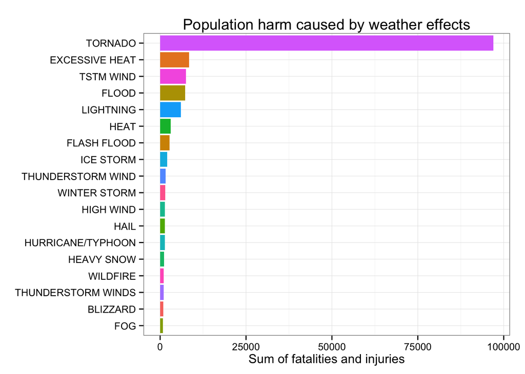

```r
library(ggplot2)
ggplot(event.high, aes(x=reorder(evtype, total), y=total, fill = evtype)) +
    theme_bw() + geom_bar(stat="identity") + coord_flip() +
    ggtitle("Population harm caused by weather effects") +
    theme(axis.title.y = element_blank(), legend.position = "none") +
    ylab("Sum of fatalities and injuries")
```

And the weather events with the greatest economic consequences.

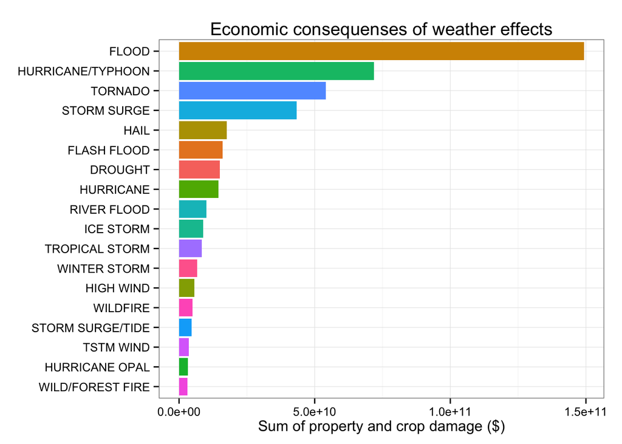

```r
ggplot(damage.high, aes(x=reorder(evtype, total), y=total, fill = evtype)) +
    theme_bw() + geom_bar(stat="identity") + coord_flip() +
    theme(axis.title.y = element_blank(), legend.position = "none") +
    ggtitle("Economic consequenses of weather effects") +
    ylab("Sum of property and crop damage ($)")
```